# dami_qame_1

### Contents:

.

## 1. Report summary

### 1.1. Substance

goal:

The goal of this problem is to make you (very!) familiar with the concept of frequent itemset, including their search space, the Apriori algorithm for finding them, as well as practical use and implications of finding frequent itemsets in real data.

```
How did you approach the problem? What kind of choices did you make and why?
```

- languages, tools, libraries, R+arules
- teamtools: irc, google-docs
- Read the subchapter 6.1 - 6.2
- tried out eclat and R arules to get some reference
- explored the data with simple statistics, plots
- Tried to implement our Apriori-algorithm
- explore changing threshold (plot steal from books or invent new

  In hindsight, propose improvements to solving the problem.
- dense-dense matrix for candidate generator , makes sense?

Remember that many of the problems are open and no perfect or right solutions exist, so do not try to find one. Instead, try to understand and describe what the methods you consider can do and what not. Propose ideas that could perhaps be helpful in solving the remaining issues.

### 1.2. Group learning:

```
What did you set as your learning objectives for this problem?
```

- To get ourselves familiar with problem based learning
- really get to understand the frequent itemsets

  How did you study and learn as a group?
- meeting face-to-face after the lectures
- IRC (hints of extra material)
- googledocs

  How did you divide and organize work in the group?
- mostly everyone does everything
- if specail intrerest, do that
- e.g. treshold-plots who has time
- understanding this particular data
- implementation details of algorithms, data-stuructures

### 1.3. Group self evaluation:

```
Did the group work well together? Why?
```

- we can speak , why wouldn’t it?

  Did all group members contribute at least satisfactorily?
- yes How will you improve the way your group works?
- we use more googe-docs and IRC

### 1.4. Evaluation of the problem and teaching:

```
Was the problem too large or too small? Was it too difficult or too easy? Too specific or too vague?
```

- positive: you can scale easily to how much time you have
- vague but ok, left room for creativity

  Did you have, as a group, suitable background to work on the problem?
- yes.

  How could the problem description be improved (for the next course of later problems in this course)?
- What chapters to read exactly How could teaching be improved?
- not enough time for group working

### 1.5. Other comments, ideas, observations, feedback?

- none so far

.

## 2. Init

```r
# init:
mycolors <- brewer.pal(8, "Dark2")
minsup <- 0.32  # minimal treshold that still yields a 4-itemset
mink <- 2  # 1-itemsets are not very interesting
maxk <- 15  # just something big enough
```

.

## 3. Reading the data in and exploring it

### Data-rows have duplicates:

```r
courses.tr <- read.transactions("course-text.txt", rm.duplicates = TRUE)
```

```
## distribution of transactions with duplicates:
##  1
## 13
```

.

### Data has 99 unique course-labels, not 106 as README.txt claims:

```r
summary(courses.tr)
```

```
## transactions as itemMatrix in sparse format with
##  2401 rows (elements/itemsets/transactions) and
##  99 columns (items) and a density of 0.1309
##
## most frequent items:
##   programming_project computer_organization  introduction_to_unix
##                  1498                  1209                  1081
##   information_systems       data_structures               (Other)
##                  1071                  1069                 25178
##
## element (itemset/transaction) length distribution:
## sizes
##   1   2   3   4   5   6   7   8   9  10  11  12  13  14  15  16  17  18
## 209 161 138 124  95 113 104  79  74  65  58  54  58  65  57  55  35  39
##  19  20  21  22  23  24  25  26  27  28  29  30  31  32  33  34  35  37
##  64  70  78  76  84  84  85  71  61  47  30  19  14  12  11   6   3   1
##  39  40
##   1   1
##
##    Min. 1st Qu.  Median    Mean 3rd Qu.    Max.
##       1       4      11      13      22      40
##
## includes extended item information - examples:
##                                              labels
## 1                                      ai_languages
## 2         algoritmisen_tietojenkäsittelyn_perusteet
## 3 an_introduction_to_specification_and_verification
```

```r
# colnames(courses.tr)
```

.

### Courses are not evenly distributed:

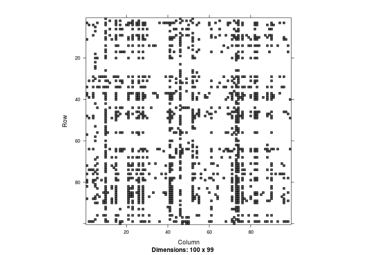

```r
image(courses.tr[1:100, ])
```

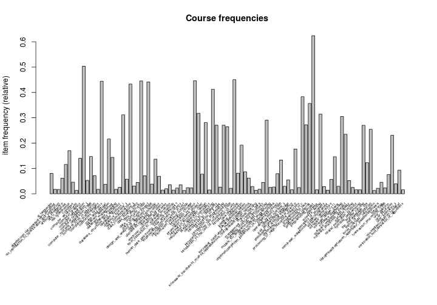

```r
itemFrequencyPlot(courses.tr, support = 0, cex.names = 0.5, main = "Course frequencies")
```

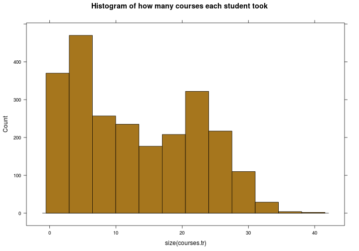

```r
histogram(size(courses.tr), type = "count", main = "Histogram of how many courses each student took",
    col = mycolors[7])
```

.

### Effect of support treshold on the number of frequent itemsets:

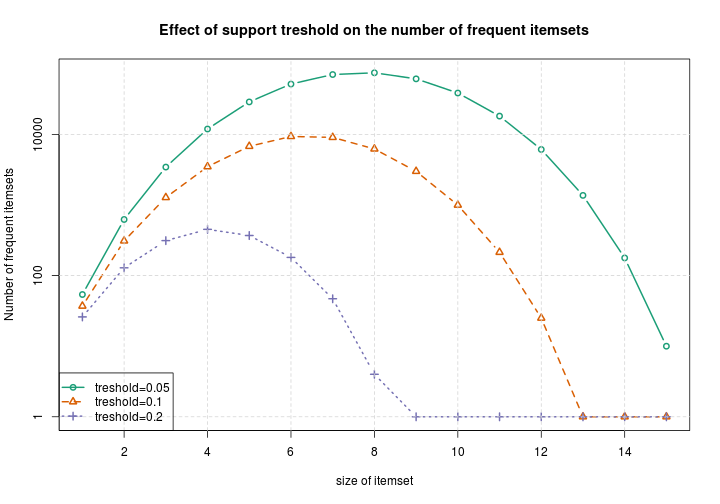

```r
fisets005 <- eclat(courses.tr, parameter = list(support = 0.05, maxlen = 99))
fisets010 <- eclat(courses.tr, parameter = list(support = 0.1, maxlen = 99))
fisets020 <- eclat(courses.tr, parameter = list(support = 0.2, maxlen = 99))
tabu005 <- tabulate(size(fisets005))
tabu010 <- tabulate(size(fisets010))
tabu020 <- tabulate(size(fisets020))
counts <- matrix(1, length(tabu005), 3)
counts[1:length(tabu005), 1] <- tabu005
counts[1:length(tabu010), 2] <- tabu010
counts[1:length(tabu020), 3] <- tabu020
matplot(counts, pch = 1:3, lwd = 2, col = mycolors, type = "b", log = "y", xlab = "size of itemset",
    ylab = "Number of frequent itemsets", main = "Effect of support treshold on the number of frequent itemsets")
grid(lty = 2)
legend("bottomleft", pch = 1:3, lwd = 2, lty = 1:3, col = mycolors, legend = c(paste("treshold=",
    c(0.05, 0.1, 0.2), sep = "")))
```

.

## 4. Reference frequent itemsets created by euclat-algorithm

```r
courses.tr <- read.transactions("course-text.txt", rm.duplicates = TRUE)
```

```r
ptm <- proc.time()
fisets <- eclat(courses.tr, parameter = list(support = minsup, minlen = mink,
    maxlen = maxk))
```

```
##
## parameter specification:
##  tidLists support minlen maxlen            target   ext
##     FALSE    0.32      2     15 frequent itemsets FALSE
##
## algorithmic control:
##  sparse sort verbose
##       7   -2    TRUE
##
## eclat - find frequent item sets with the eclat algorithm
## version 2.6 (2004.08.16)         (c) 2002-2004   Christian Borgelt
## create itemset ...
## set transactions ...[99 item(s), 2401 transaction(s)] done [0.00s].
## sorting and recoding items ... [11 item(s)] done [0.00s].
## creating bit matrix ... [11 row(s), 2401 column(s)] done [0.00s].
## writing  ... [37 set(s)] done [0.00s].
## Creating S4 object  ... done [0.00s].
```

```r
proc.time() - ptm
```

```
##    user  system elapsed
##   0.036   0.000   0.037
```

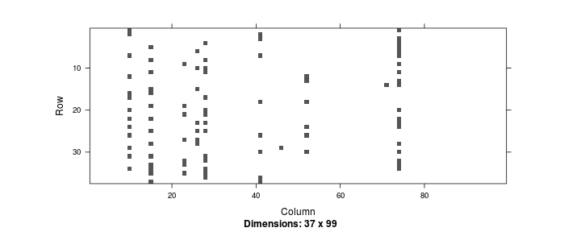

```r
image(items(sort(fisets, by = "support")))
```

```r
inspect(head(sort(fisets, by = "support"), n = 3))
```

```
##   items                   support
## 1 {computer_organization,
##    programming_project}    0.4573
## 2 {computer_organization,
##    information_systems}    0.4182
## 3 {information_systems,
##    programming_project}    0.4132
```

```r
str(LIST(items(sort(fisets, by = "support"))))
```

```
## List of 37
##  $ : chr [1:2] "computer_organization" "programming_project"
##  $ : chr [1:2] "computer_organization" "information_systems"
##  $ : chr [1:2] "information_systems" "programming_project"
##  $ : chr [1:2] "data_structures_project" "programming_project"
##  $ : chr [1:2] "concurrent_systems" "programming_project"
##  $ : chr [1:2] "data_structures" "programming_project"
##  $ : chr [1:3] "computer_organization" "information_systems" "programming_project"
##  $ : chr [1:2] "concurrent_systems" "data_structures_project"
##  $ : chr [1:2] "data_communications" "programming_project"
##  $ : chr [1:2] "data_structures" "data_structures_project"
##  $ : chr [1:3] "concurrent_systems" "data_structures_project" "programming_project"
##  $ : chr [1:2] "computer_organization" "introduction_to_unix"
##  $ : chr [1:2] "introduction_to_unix" "programming_project"
##  $ : chr [1:2] "programming_in_c" "programming_project"
```

[output cut: 23 more lines]

.

## 5. Arto Nissinen (try own implementation of apriori-algorithm)

- Used data-structures: from R package 'arules' (itemMatrix, itemsets, transactions) that all use sparse-matrix implementation 'ngCMatrix' from the R package 'Matrix'.
- Why? I wanted to learn how to use sparse-matrices and S4-objects.
- Pros: Efficient memory usage. Easy to plot debug-visualizations.
- Cons: Unnecessary complexity for data this small.
- Used: from the R arules-library read.transactions() and support() to count supports, which resulted in considerable speed-up.

```r
courses.tr <- read.transactions("course-text.txt", rm.duplicates = TRUE)
```

```
## distribution of transactions with duplicates:
##  1
## 13
```

```
## k =  2
## NULL
## Ck= 2  image of candidates after pruning:
```

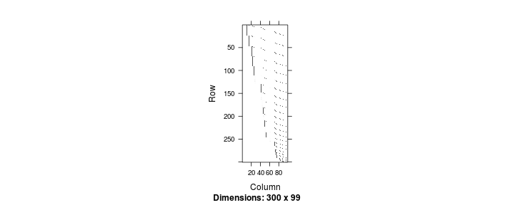

```
## k =  3
## [1]  2 88
## Ck= 3  image of candidates after pruning:
```

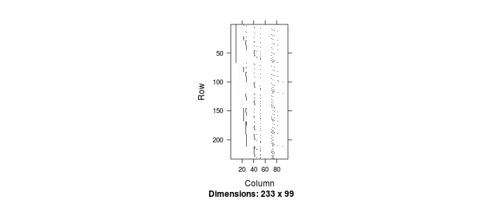

```
## k =  4
## [1]   3 172
## Ck= 4  image of candidates after pruning:
```

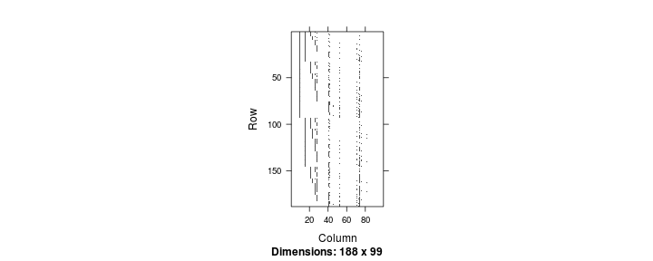

```
## k =  5
## [1]   4 166
## Ck= 5  image of candidates after pruning:
```

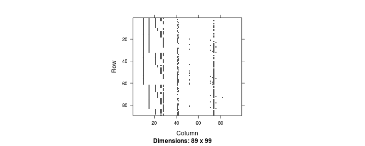

```
## k =  6
## [1]  5 79
## Ck= 6  image of candidates after pruning:
```

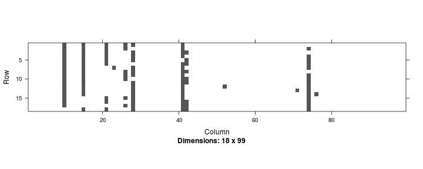

```
## k =  7
## [1]  6 16
## Ck= 7  image of candidates after pruning:
```

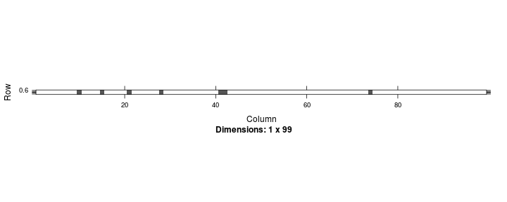

```
## k =  8
## [1] 7 1
```

```r
myapriori.gen <- function(Fk_1) {
    out.list <- list()
    count.generated <- 0
    mat <- items(Fk_1)
    m <- nrow(mat)
    n <- ncol(mat)
    idx.list <- LIST(mat, decode = FALSE)
    k_1 <- length(idx.list[[1]])
    idx.mat <- sapply(idx.list, identity)  # note! it's transposed
    print(dim(idx.mat))
    for (i in 1:m) {
        ouridxs <- idx.list[[i]]
        ourj <- ouridxs[k_1]
        k2match <- rep(TRUE, m)
        if (k_1 >= 2) {
            k2match <- colSums(idx.mat[1:(k_1 - 1), , drop = F] == ouridxs[1:(k_1 -
                1)])
            k2match <- k2match == (k_1 - 1)
        }
        tempsizes <- size(mat[, (ourj):n])
        for (ti in 1:m) {
            if (k2match[ti] & tempsizes[ti] > 0 & ti != i) {
                theiridxs <- idx.list[[ti]]
                candi <- c(ouridxs, theiridxs[length(theiridxs)])
                count.generated <- count.generated + 1
                # pruning-step: split to (k-1)-subsets and check that they are frequent
                subsetfreqsum <- 0
                if (k_1 >= 2) {
                  for (j in 1:length(candi)) {
                    subo <- candi[-j]
                    k1match <- colSums(idx.mat == subo)
                    k1match <- k1match == k_1
                    if (sum(k1match) > 0)
                      subsetfreqsum <- subsetfreqsum + 1
                  }
                } else {
                  subsetfreqsum <- k_1 + 1
                }
                if (subsetfreqsum == k_1 + 1)
                  out.list <- c(out.list, list(candi))
            }
        }
    }
    ret <- encode(out.list, itemLabels = itemLabels(Fk_1), itemMatrix = TRUE)
    ret <- new("itemsets", items = ret)
    # returning:
    list(Ck = ret, counts = c(count.generated, length(ret)))
}

myapriori <- function(data.tr, minsup = 0.4, mink = 1, maxk = 100) {
    Fk.list <- list()
    counts.list <- list()
    k <- 1  # line 1
    # line 2: Find all frequent 1-itemsets
    temp.freq <- as.numeric(itemFrequency(data.tr))
    idxs <- which(temp.freq >= minsup)
    if (length(idxs) == 0)
        stop("no frequent 1-itemsets")
    temp.mat <- matrix(0L, nrow = length(idxs), ncol = ncol(data.tr))
    colnames(temp.mat) <- colnames(data.tr)
    for (i in 1:length(idxs)) {
        temp.mat[i, idxs[i]] <- 1L
    }
    temp.quality <- data.frame(support = temp.freq[idxs])
    Fk.list[[k]] <- new("itemsets", items = as(temp.mat, "itemMatrix"), quality = temp.quality)
    counts.list[[k]] <- c(NA, NA, length(Fk.list[[k]]))
    cont <- TRUE  # line 3: repeat
    while (cont) {
        k <- k + 1  # line 4
        cat("k = ", k, "\n")
        ret <- myapriori.gen(Fk.list[[k - 1]])  # line 5: generate candidate itemsets
        Ck <- ret$Ck
        counts <- ret$counts
        if (length(Ck) == 0) {
            cont <- FALSE
        } else {
            cat("Ck=", k, " image of candidates after pruning:\n")
            print(image(items(Ck), main = "Ck candidates"))
        }
        # lines 6-11: calculate supports for candidates
        supports <- support(Ck, data.tr)
        quality(Ck) <- data.frame(support = supports)
        Fk.list[k] <- Ck[supports >= minsup, ]  # line 12
        counts.list[[k]] <- c(counts, length(Fk.list[[k]]))
        # line 13: until
        if (k >= ncol(data.tr) || k >= maxk || length(Fk.list[[k]]) == 0)
            cont <- FALSE
    }
    # line 14, return the union of Fks
    ret <- Fk.list[[mink]]
    for (i in (mink + 1):length(Fk.list)) {
        ret <- union(ret, Fk.list[[i]])
    }
    counts <- t(sapply(counts.list, identity))
    counts[counts == 0] <- NA
    colnames(counts) <- c("generated_candidates", "after_pruning", "after_support_counting")
    # returning
    list(fisets = ret, counts = counts)
}

# Calling the function
ptm <- proc.time()
ret <- myapriori(courses.tr, minsup = 0.23, mink = 6, maxk = 15)
```

```r
proc.time() - ptm
```

```
##    user  system elapsed
##   8.461   0.052   8.554
```

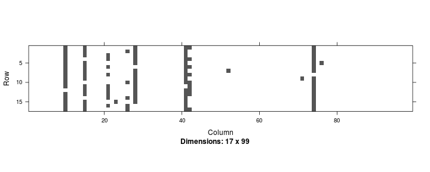

```r
temp <- ret$fisets
image(items(sort(temp, by = "support")))
```

```r
inspect(head(sort(temp, by = "support"), n = 3))
```

```
##   items                         support
## 1 {computer_organization,
##    concurrent_systems,
##    data_structures_project,
##    information_systems,
##    information_systems_project,
##    programming_project}          0.2536
## 2 {computer_organization,
##    concurrent_systems,
##    data_structures,
##    data_structures_project,
##    information_systems,
##    programming_project}          0.2528
## 3 {computer_organization,
##    concurrent_systems,
##    database_systems_i,
##    data_structures_project,
##    information_systems,
##    programming_project}          0.2520
```

```r
str(LIST(items(sort(temp, by = "support"))))
```

```
## List of 17
##  $ : chr [1:6] "computer_organization" "concurrent_systems" "data_structures_project" "information_systems" ...
##  $ : chr [1:6] "computer_organization" "concurrent_systems" "data_structures" "data_structures_project" ...
##  $ : chr [1:6] "computer_organization" "concurrent_systems" "database_systems_i" "data_structures_project" ...
##  $ : chr [1:6] "computer_organization" "database_systems_i" "data_structures_project" "information_systems" ...
##  $ : chr [1:6] "computer_organization" "concurrent_systems" "data_structures_project" "information_systems" ...
##  $ : chr [1:6] "computer_organization" "concurrent_systems" "database_systems_i" "information_systems" ...
##  $ : chr [1:6] "computer_organization" "concurrent_systems" "data_structures_project" "information_systems" ...
##  $ : chr [1:6] "computer_organization" "concurrent_systems" "database_systems_i" "data_structures_project" ...
##  $ : chr [1:6] "computer_organization" "concurrent_systems" "data_structures_project" "information_systems" ...
##  $ : chr [1:6] "computer_organization" "data_structures" "data_structures_project" "information_systems" ...
##  $ : chr [1:6] "computer_organization" "concurrent_systems" "database_systems_i" "data_structures_project" ...
##  $ : chr [1:6] "concurrent_systems" "database_systems_i" "data_structures_project" "information_systems" ...
##  $ : chr [1:7] "computer_organization" "concurrent_systems" "database_systems_i" "data_structures_project" ...
##  $ : chr [1:6] "computer_organization" "database_systems_i" "data_structures" "data_structures_project" ...
##  $ : chr [1:6] "computer_organization" "concurrent_systems" "data_communications" "data_structures_project" ...
##  $ : chr [1:6] "computer_organization" "concurrent_systems" "database_systems_i" "data_structures" ...
##  $ : chr [1:6] "computer_organization" "concurrent_systems" "data_structures" "information_systems" ...
```

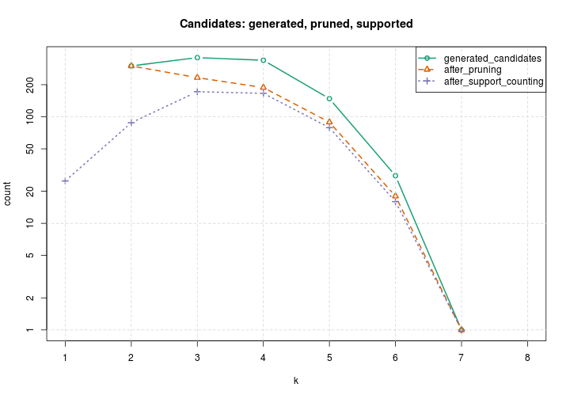

```r
matplot(ret$counts, pch = 1:3, lwd = 2, col = mycolors[1:3], type = "b", log = "y",
    xlab = "k", ylab = "count", main = "Candidates: generated, pruned, supported")
grid(lty = 2)
legend("topright", pch = 1:3, lwd = 2, lty = 1:3, col = mycolors[1:3], legend = colnames(ret$counts))
```

.

.

.

## 8. Quan Nguyen (try own implementation of apriori-algorithm)

```r
Candidate <- function(F) {
    n = ncol(F)
    m = nrow(F)
    cnt = 1
    Cdt = list(0)

    if (m > 1) {
        for (i in 1:n) {
            ii = i + 1
            while (ii <= n) {
                if (identical(F[1:m - 1, i], F[1:m - 1, ii])) {
                  Cdt[[1]][cnt] = list(c(F[, i], F[m, ii]))
                  cnt = cnt + 1
                }
                ii = ii + 1
            }
        }
    } else {
        for (i in 1:n) {
            ii = i + 1
            while (ii <= n) {
                Cdt[[1]][cnt] = list(c(F[i], F[ii]))
                cnt = cnt + 1
                ii = ii + 1
            }
        }
    }
    return(Cdt)
}
```

```r
Apriori <- function(D, thres) {
    X = unique(unlist(D))
    threshold = thres * length(D)
    cnt = 1
    F = list(0)

    for (i in 1:length(X)) {
        s = 0
        for (ii in 1:length(D)) {
            s = s + sum(which(D[[ii]] == X[i]) != 0)
        }
        if (s >= threshold) {
            F[[1]][cnt] = X[i]
            cnt = cnt + 1
        }
    }

    k = 1
    while (1) {
        if (k == 1) {
            Cdt = Candidate(do.call(rbind, F[1]))
        } else {
            Cdt = Candidate(t(do.call(rbind, F[[k]])))
        }

        k = k + 1
        sup = matrix(0, 1, length(Cdt[[1]]))
        for (ii in 1:length(Cdt[[1]])) {
            for (iii in 1:length(D)) {
                if (sum(which(match(rbind(Cdt[[1]][[ii]]), rbind(D[[iii]])) !=
                  0) != 0) == k) {
                  sup[ii] = sup[ii] + 1
                }
            }
        }
        F[[k]] = Cdt[[1]][which(sup >= threshold)]
        if (length(F[[k]]) == 0) {
            break
        }
    }
    return(F)
}
```

```r
ptm <- proc.time()
F.list = Apriori(strsplit(readLines("course-text.txt"), " "), minsup)
proc.time() - ptm
```

```
##    user  system elapsed
##  32.774   0.368  33.180
```

```r
str(F.list)
```

```
## List of 5
##  $ : chr [1:11] "computer_organization" "introduction_to_unix" "introduction_to_computing" "programming_project" ...
##  $ :List of 22
##   ..$ : chr [1:2] "computer_organization" "introduction_to_unix"
##   ..$ : chr [1:2] "computer_organization" "introduction_to_computing"
##   ..$ : chr [1:2] "computer_organization" "programming_project"
##   ..$ : chr [1:2] "computer_organization" "concurrent_systems"
##   ..$ : chr [1:2] "computer_organization" "information_systems"
##   ..$ : chr [1:2] "computer_organization" "data_structures_project"
##   ..$ : chr [1:2] "introduction_to_unix" "programming_project"
##   ..$ : chr [1:2] "introduction_to_unix" "information_systems"
##   ..$ : chr [1:2] "programming_project" "data_structures"
##   ..$ : chr [1:2] "programming_project" "data_communications"
##   ..$ : chr [1:2] "programming_project" "concurrent_systems"
##   ..$ : chr [1:2] "programming_project" "information_systems"
##   ..$ : chr [1:2] "programming_project" "data_structures_project"
##   ..$ : chr [1:2] "programming_project" "programming_in_c"
##   ..$ : chr [1:2] "data_structures" "data_communications"
##   ..$ : chr [1:2] "data_structures" "concurrent_systems"
##   ..$ : chr [1:2] "data_structures" "data_structures_project"
##   ..$ : chr [1:2] "data_communications" "concurrent_systems"
##   ..$ : chr [1:2] "data_communications" "data_structures_project"
##   ..$ : chr [1:2] "concurrent_systems" "information_systems"
##   ..$ : chr [1:2] "concurrent_systems" "data_structures_project"
##   ..$ : chr [1:2] "information_systems" "data_structures_project"
##  $ :List of 14
##   ..$ : chr [1:3] "computer_organization" "introduction_to_unix" "programming_project"
##   ..$ : chr [1:3] "computer_organization" "introduction_to_unix" "information_systems"
##   ..$ : chr [1:3] "computer_organization" "programming_project" "concurrent_systems"
##   ..$ : chr [1:3] "computer_organization" "programming_project" "information_systems"
##   ..$ : chr [1:3] "computer_organization" "programming_project" "data_structures_project"
##   ..$ : chr [1:3] "computer_organization" "concurrent_systems" "data_structures_project"
##   ..$ : chr [1:3] "introduction_to_unix" "programming_project" "information_systems"
##   ..$ : chr [1:3] "programming_project" "data_structures" "concurrent_systems"
##   ..$ : chr [1:3] "programming_project" "data_structures" "data_structures_project"
##   ..$ : chr [1:3] "programming_project" "data_communications" "concurrent_systems"
##   ..$ : chr [1:3] "programming_project" "data_communications" "data_structures_project"
##   ..$ : chr [1:3] "programming_project" "concurrent_systems" "data_structures_project"
##   ..$ : chr [1:3] "data_structures" "concurrent_systems" "data_structures_project"
##   ..$ : chr [1:3] "data_communications" "concurrent_systems" "data_structures_project"
##  $ :List of 1
##   ..$ : chr [1:4] "computer_organization" "programming_project" "concurrent_systems" "data_structures_project"
##  $ : num(0)
```